# Vaccine allocation project results

GMB

2022-08-02

# 1 Introduction

This document brings together results from multiple model runs. It is intended to be re-run as the model is updated.

NOTE: The setting for this run is: SLE

**Focus questions:**

- What impact will the existing vaccination plan have on morbidity and mortality?
- What impact can be achieved under different levels of vaccine coverage?
- What are the potential benefits of expanding the immunisation schedule to include children?

**Overarching assumptions**

Unless otherwise specified, key model parameters in this run are:

| Variable | Value | Source |
| --- | --- | --- |
| Circulating strain | omicron |  |
| Length of model run | 2 |  |
| Current vaccine coverage | dose one: 32%; dose two: 23% | John Hopkins COVID-19 vaccination data |
| Current vaccine coverage target | 51.6% | Government target in COVAX documentation May 2021 |
| Proportion of population willing to be vaccinated | 88% | Survey estimating vaccine acceptance in January 2021 (Solis et al., 2021) |
| Daily capacity for vaccination (doses) | 11075 | Slightly lower than the pilot vaccination campaign October-November 2021 |
| Anticipated type of future vaccine doses | Johnson & Johnson | The Government of Sierra Leone has demonstrated a strong preference for this vaccine, negotiating with major donors, such as the Government of Italy, to change their donations of double-dose vaccines … |
| Interval between doses | 90 days |  |
| Waning of VE against acquisition | TRUE |  |
| Waning of VE against severe disease | FALSE |  |
| Waning of infection-derived immunity against acquisition | TRUE |  |
| Waning of infection-derived immunity against severe outcomes | Not yet included |  |
| YLL discounting | 0 |  |

**Other assumptions/limitations:**

- Linear roll-out of vaccines (Lowy Institute report and trends in the ACT do not support this)
- Vaccine effectiveness estimates last updated on the 14th of April 2022 from WHO live systematic review (https://view-hub.org/covid-19/effectiveness-studies)

**Next steps for noting:**

- update of infection- and vaccine-derived immunity
- sensitivity analysis
  - turning on/off waning of vaccine-derived immunity
  - simulating outbreaks of different strains
  - experimenting with different age-prioritisation strategies
  - other?

# 2 Impact of current program targets

Roll out of current program target (51.6% coverage) during or prior to an outbreak:

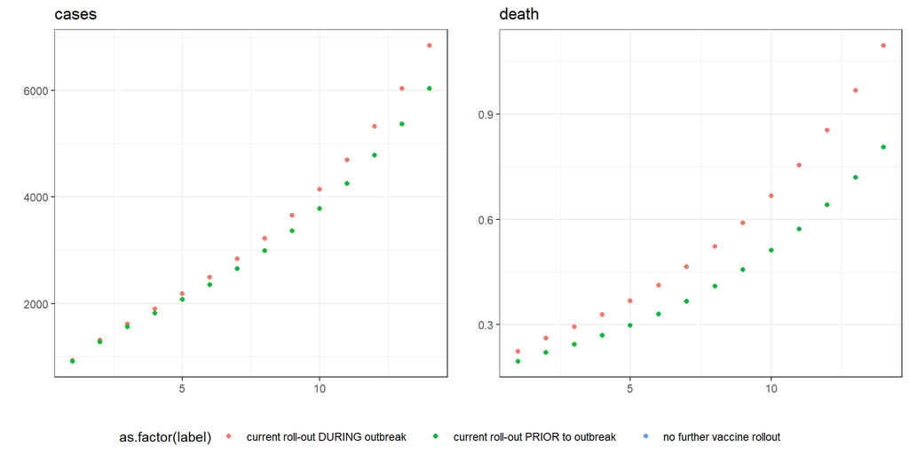

Absolute difference in outcomes (compared to no further vaccine roll-out)

| scenario | death | hosp | severe_disease | YLL | cases |
| --- | --- | --- | --- | --- | --- |
| current roll-out DURING outbreak | 0 | 0 | 0 | 0 | 0 |
| current roll-out PRIOR to outbreak | 2 | 112 | 30 | 24 | 3,973 |

Relative difference in outcomes

| scenario | death | hosp | severe_disease | YLL | cases |
| --- | --- | --- | --- | --- | --- |
| current roll-out DURING outbreak | 0.0 | 0.0 | 0.00 | 0.00 | 0.00 |
| current roll-out PRIOR to outbreak | 22.6 | 17.1 | 23.29 | 20.05 | 8.42 |

# 3 Varying levels of coverage

## 3.1 Using current age-specific eligiblity

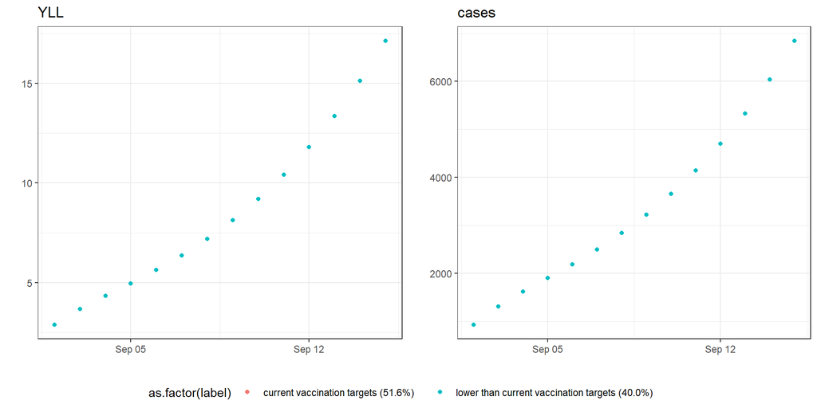

Absolute difference in outcomes (compared to current vaccine targets)

| scenario | macro_age_group | death | hosp | severe_disease | YLL | cases |
| --- | --- | --- | --- | --- | --- | --- |
| lower than current vaccination targets (40.0%) | adults | 0 | 0 | 0 | 0 | 0 |
| lower than current vaccination targets (40.0%) | children | 0 | 0 | 0 | 0 | 0 |
| lower than current vaccination targets (40.0%) | net | 0 | 0 | 0 | 0 | 0 |

Relative difference in outcomes (%)

| scenario | macro_age_group | death | hosp | severe_disease | YLL | cases |
| --- | --- | --- | --- | --- | --- | --- |
| lower than current vaccination targets (40.0%) | adults | 0 | 0 | 0 | 0 | 0 |
| lower than current vaccination targets (40.0%) | children | 0 | 0 | 0 | 0 | 0 |
| lower than current vaccination targets (40.0%) | net | 0 | 0 | 0 | 0 | 0 |

## 3.2 Expanding eligibility to children (DURING an outbreak)

### 3.2.1 Run current vaccine campaign, then expand to children

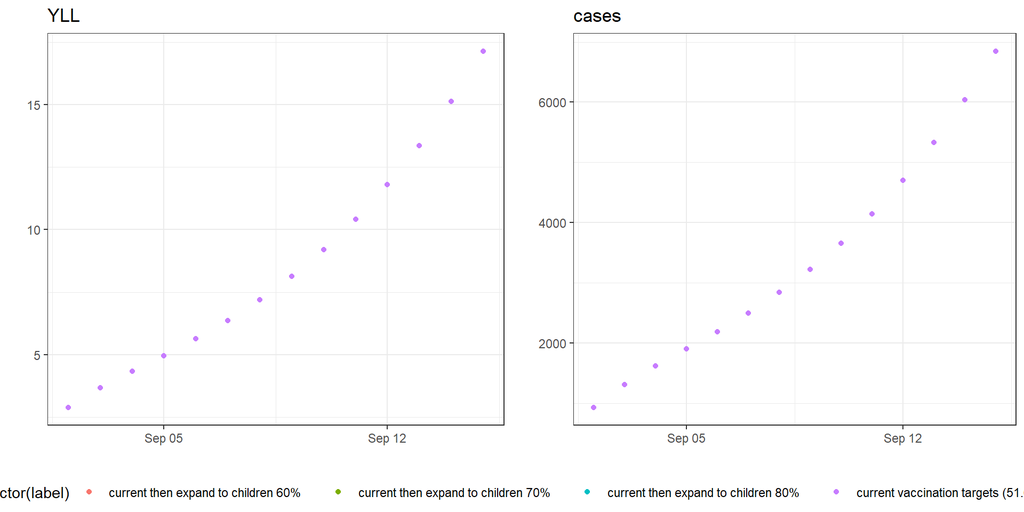

Absolute difference in outcomes (compared to current vaccine targets)

| scenario | macro_age_group | death | hosp | severe_disease | YLL | cases |
| --- | --- | --- | --- | --- | --- | --- |
| current then expand to children 60% | adults | 0 | 0 | 0 | 0 | 0 |
| current then expand to children 60% | children | 0 | 0 | 0 | 0 | 0 |
| current then expand to children 60% | net | 0 | 0 | 0 | 0 | 0 |
| current then expand to children 70% | adults | 0 | 0 | 0 | 0 | 0 |
| current then expand to children 70% | children | 0 | 0 | 0 | 0 | 0 |
| current then expand to children 70% | net | 0 | 0 | 0 | 0 | 0 |
| current then expand to children 80% | adults | 0 | 0 | 0 | 0 | 0 |
| current then expand to children 80% | children | 0 | 0 | 0 | 0 | 0 |
| current then expand to children 80% | net | 0 | 0 | 0 | 0 | 0 |

Relative difference in outcomes (%)

| scenario | macro_age_group | death | hosp | severe_disease | YLL | cases |
| --- | --- | --- | --- | --- | --- | --- |
| current then expand to children 60% | adults | 0 | 0 | 0 | 0 | 0 |
| current then expand to children 60% | children | 0 | 0 | 0 | 0 | 0 |
| current then expand to children 60% | net | 0 | 0 | 0 | 0 | 0 |
| current then expand to children 70% | adults | 0 | 0 | 0 | 0 | 0 |
| current then expand to children 70% | children | 0 | 0 | 0 | 0 | 0 |
| current then expand to children 70% | net | 0 | 0 | 0 | 0 | 0 |
| current then expand to children 80% | adults | 0 | 0 | 0 | 0 | 0 |
| current then expand to children 80% | children | 0 | 0 | 0 | 0 | 0 |
| current then expand to children 80% | net | 0 | 0 | 0 | 0 | 0 |

### 3.2.2 Expand to children now

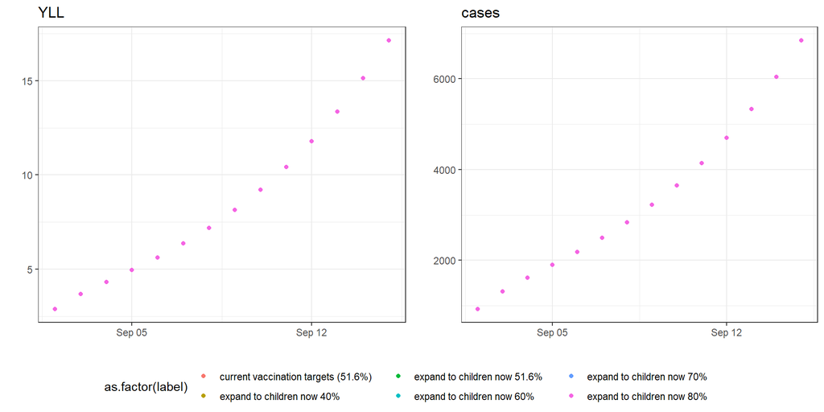

Absolute difference in outcomes (compared to current vaccine targets)

| scenario | macro_age_group | death | hosp | severe_disease | YLL | cases |
| --- | --- | --- | --- | --- | --- | --- |
| expand to children now 40% | adults | 0 | 0 | 0 | 0 | 0 |
| expand to children now 40% | children | 0 | 0 | 0 | 0 | 0 |
| expand to children now 40% | net | 0 | 0 | 0 | 0 | 0 |
| expand to children now 51.6% | adults | 0 | 0 | 0 | 0 | 0 |
| expand to children now 51.6% | children | 0 | 0 | 0 | 0 | 0 |
| expand to children now 51.6% | net | 0 | 0 | 0 | 0 | 0 |
| expand to children now 60% | adults | 0 | 0 | 0 | 0 | 0 |
| expand to children now 60% | children | 0 | 0 | 0 | 0 | 0 |
| expand to children now 60% | net | 0 | 0 | 0 | 0 | 0 |
| expand to children now 70% | adults | 0 | 0 | 0 | 0 | 0 |
| expand to children now 70% | children | 0 | 0 | 0 | 0 | 0 |
| expand to children now 70% | net | 0 | 0 | 0 | 0 | 0 |
| expand to children now 80% | adults | 0 | 0 | 0 | 0 | 0 |
| expand to children now 80% | children | 0 | 0 | 0 | 0 | 0 |
| expand to children now 80% | net | 0 | 0 | 0 | 0 | 0 |

Relative difference in outcomes (%)

| scenario | macro_age_group | death | hosp | severe_disease | YLL | cases |
| --- | --- | --- | --- | --- | --- | --- |
| expand to children now 40% | adults | 0 | 0 | 0 | 0 | 0 |
| expand to children now 40% | children | 0 | 0 | 0 | 0 | 0 |
| expand to children now 40% | net | 0 | 0 | 0 | 0 | 0 |
| expand to children now 51.6% | adults | 0 | 0 | 0 | 0 | 0 |
| expand to children now 51.6% | children | 0 | 0 | 0 | 0 | 0 |
| expand to children now 51.6% | net | 0 | 0 | 0 | 0 | 0 |
| expand to children now 60% | adults | 0 | 0 | 0 | 0 | 0 |
| expand to children now 60% | children | 0 | 0 | 0 | 0 | 0 |
| expand to children now 60% | net | 0 | 0 | 0 | 0 | 0 |
| expand to children now 70% | adults | 0 | 0 | 0 | 0 | 0 |
| expand to children now 70% | children | 0 | 0 | 0 | 0 | 0 |
| expand to children now 70% | net | 0 | 0 | 0 | 0 | 0 |
| expand to children now 80% | adults | 0 | 0 | 0 | 0 | 0 |
| expand to children now 80% | children | 0 | 0 | 0 | 0 | 0 |
| expand to children now 80% | net | 0 | 0 | 0 | 0 | 0 |

## 3.3 Expanding eligibility to children (PRIOR TO an outbreak)

Note: If waning immunity against severe outcomes ON, this looks like a bad idea.

### 3.3.1 Run current vaccine campaign, then expand to children

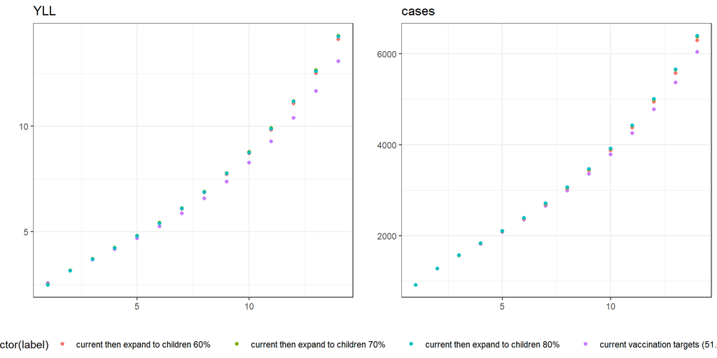

Absolute difference in outcomes (compared to current vaccine targets)

| scenario | macro_age_group | death | hosp | severe_disease | YLL | cases |
| --- | --- | --- | --- | --- | --- | --- |
| current then expand to children 60% | adults | -1 | -37 | -11 | -8 | -3,073 |
| current then expand to children 60% | children | 0 | 34 | 1 | 3 | 2,018 |
| current then expand to children 60% | net | -1 | -3 | -10 | -5 | -1,055 |
| current then expand to children 70% | adults | -1 | -48 | -14 | -10 | -3,887 |
| current then expand to children 70% | children | 0 | 52 | 1 | 5 | 2,462 |
| current then expand to children 70% | net | -1 | 4 | -13 | -5 | -1,426 |
| current then expand to children 80% | adults | -1 | -51 | -15 | -11 | -4,044 |
| current then expand to children 80% | children | 0 | 61 | 1 | 6 | 2,548 |
| current then expand to children 80% | net | -1 | 11 | -13 | -5 | -1,496 |

Relative difference in outcomes (%)

| scenario | macro_age_group | death | hosp | severe_disease | YLL | cases |
| --- | --- | --- | --- | --- | --- | --- |
| current then expand to children 60% | adults | -9.80 | -11.26 | -10.93 | -10.69 | -12.13 |
| current then expand to children 60% | children | 14.99 | 15.74 | 17.75 | 14.32 | 11.28 |
| current then expand to children 60% | net | -8.31 | -0.59 | -10.01 | -4.91 | -2.44 |
| current then expand to children 70% | adults | -12.88 | -14.73 | -14.31 | -14.01 | -15.34 |
| current then expand to children 70% | children | 23.26 | 24.40 | 27.45 | 22.25 | 13.75 |
| current then expand to children 70% | net | -10.70 | 0.74 | -12.98 | -5.63 | -3.30 |
| current then expand to children 80% | adults | -13.48 | -15.41 | -14.96 | -14.66 | -15.96 |
| current then expand to children 80% | children | 27.23 | 28.54 | 32.07 | 26.07 | 14.24 |
| current then expand to children 80% | net | -11.02 | 1.97 | -13.46 | -5.24 | -3.46 |

### 3.3.2 Expand to children now

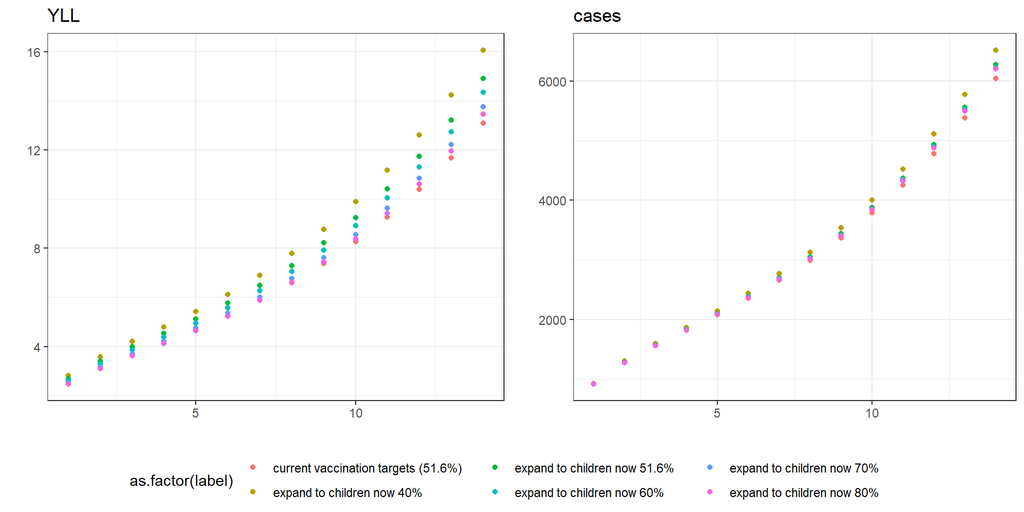

Absolute difference in outcomes (compared to current vaccine targets)

| scenario | macro_age_group | death | hosp | severe_disease | YLL | cases |
| --- | --- | --- | --- | --- | --- | --- |
| expand to children now 40% | adults | -1 | -86 | -25 | -19 | -2,996 |
| expand to children now 40% | children | 0 | 11 | 0 | 1 | 643 |
| expand to children now 40% | net | -1 | -76 | -25 | -18 | -2,354 |
| expand to children now 51.6% | adults | -1 | -63 | -18 | -14 | -2,530 |
| expand to children now 51.6% | children | 0 | 31 | 1 | 3 | 1,533 |
| expand to children now 51.6% | net | -1 | -32 | -18 | -11 | -996 |
| expand to children now 60% | adults | -1 | -50 | -15 | -11 | -2,432 |
| expand to children now 60% | children | 0 | 40 | 1 | 4 | 1,705 |
| expand to children now 60% | net | -1 | -10 | -14 | -7 | -727 |
| expand to children now 70% | adults | -1 | -36 | -10 | -8 | -2,388 |
| expand to children now 70% | children | 0 | 51 | 1 | 5 | 1,770 |
| expand to children now 70% | net | 0 | 14 | -10 | -3 | -618 |
| expand to children now 80% | adults | 0 | -29 | -8 | -6 | -2,376 |
| expand to children now 80% | children | 0 | 56 | 1 | 5 | 1,784 |
| expand to children now 80% | net | 0 | 27 | -7 | -1 | -592 |

Relative difference in outcomes (%)

| scenario | macro_age_group | death | hosp | severe_disease | YLL | cases |
| --- | --- | --- | --- | --- | --- | --- |
| expand to children now 40% | adults | -25.34 | -26.33 | -26.02 | -26.08 | -11.83 |
| expand to children now 40% | children | 4.62 | 4.97 | 5.92 | 4.31 | 3.59 |
| expand to children now 40% | net | -23.53 | -13.95 | -25.00 | -19.06 | -5.44 |
| expand to children now 51.6% | adults | -17.98 | -19.09 | -18.80 | -18.75 | -9.98 |
| expand to children now 51.6% | children | 13.55 | 14.23 | 16.04 | 12.95 | 8.57 |
| expand to children now 51.6% | net | -16.08 | -5.92 | -17.69 | -11.42 | -2.30 |
| expand to children now 60% | adults | -14.10 | -15.24 | -14.96 | -14.86 | -9.60 |
| expand to children now 60% | children | 17.95 | 18.80 | 21.09 | 17.19 | 9.52 |
| expand to children now 60% | net | -12.16 | -1.78 | -13.81 | -7.45 | -1.68 |
| expand to children now 70% | adults | -9.90 | -11.07 | -10.80 | -10.64 | -9.43 |
| expand to children now 70% | children | 22.59 | 23.64 | 26.44 | 21.67 | 9.89 |
| expand to children now 70% | net | -7.94 | 2.65 | -9.61 | -3.17 | -1.43 |
| expand to children now 80% | adults | -7.68 | -8.85 | -8.58 | -8.40 | -9.38 |
| expand to children now 80% | children | 25.04 | 26.19 | 29.26 | 24.02 | 9.97 |
| expand to children now 80% | net | -5.70 | 5.00 | -7.38 | -0.90 | -1.37 |

# 4 Varying speed of vaccine roll-out

This section models varying speeds of vaccine roll-out *DURING* an outbreak.

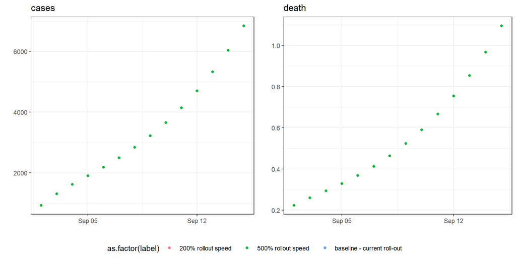

Absolute difference in outcomes (compared to current rollout speed)

| scenario | death | hosp | severe_disease | YLL | cases |
| --- | --- | --- | --- | --- | --- |
| 200% rollout speed | 0 | 0 | 0 | 0 | 0 |
| 500% rollout speed | 0 | 0 | 0 | 0 | 0 |

Relative difference in outcomes (%)

| scenario | death | hosp | severe_disease | YLL | cases |
| --- | --- | --- | --- | --- | --- |
| 200% rollout speed | 0 | 0 | 0 | 0 | 0 |
| 500% rollout speed | 0 | 0 | 0 | 0 | 0 |

# 5 Sensitivity analysis (see FleetDeputy output)

# 6 Appendix - parameter estimates

**Vaccine effectiveness estimates**

**Point estimates by type, dose and outcome**

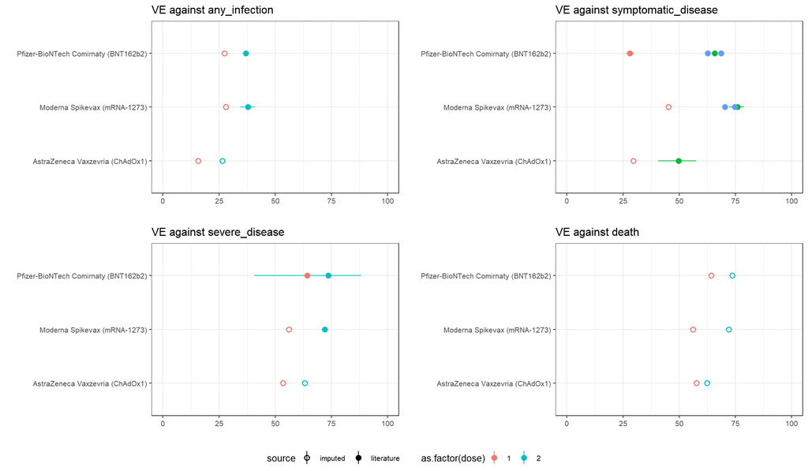

[output not shown]

**Infection-derived immunity estimate**

Rho severe outcomes: 0.88

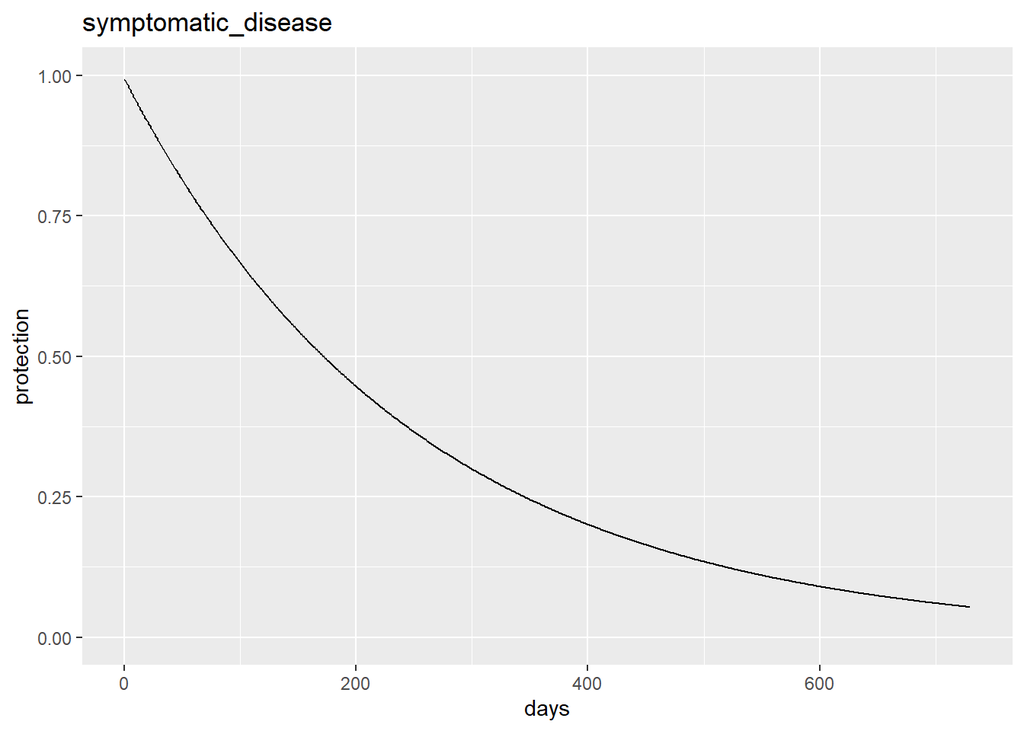

**Seroprevalence**

| age_group | seroprev |
| --- | --- |
| 0 to 4 | 7.643630 |
| 5 to 17 | 10.040014 |
| 18 to 29 | 6.607331 |
| 30 to 44 | 9.297261 |
| 45 to 59 | 19.783513 |
| 60 to 69 | 16.186511 |
| 70 to 100 | 16.186511 |

**Other key parameters**

| Variable | Value | Source |
| --- | --- | --- |
| Seed of outbreak (initially infected) | 8306.442 individuals |  |
| Delay from first dose to protection | 21 days |  |
| Delay from second dose to protection | 14 days |  |